# Prak5

Цель: составить графики, проанализировать их и провести кластеризацию.

Импортируем библиотеки из 3 практической работы с набором данных pandas и numpy. Импортируем библиотеку seaborn для построения графиков. Импортируем и библиотеку matplotlib.pyplot с упрощенными графиками.

```python
import pandas as pd
import numpy as np
import seaborn as sns
import matplotlib.pyplot as plot
from sklearn.cluster import KMeans
```

```python
df = pd.read_csv('vgsales_20.csv')
df
```

|  | Rank | Name | Platform | Year | Genre | Publisher | NA_Sales | EU_Sales | JP_Sales | Other_Sales | Global_Sales |
| --- | --- | --- | --- | --- | --- | --- | --- | --- | --- | --- | --- |
| 0 | 13368 | Gitaroo Man | PS2 | 2001.0 | Misc | THQ | 0.02 | 0.02 | 0.00 | 0.01 | 0.05 |
| 1 | 11518 | Shonen Jump's One Piece: Pirates Carnival | GC | 2005.0 | Misc | Namco Bandai Games | 0.06 | 0.02 | 0.00 | 0.00 | 0.08 |
| 2 | 14741 | Pro Evolution Soccer 2017 | XOne | 2016.0 | Sports | Konami Digital Entertainment | 0.00 | 0.02 | 0.00 | 0.00 | 0.03 |
| 3 | 7072 | Naruto Shippuden: Ninja Council 4 | DS | 2007.0 | Action | Nintendo | 0.09 | 0.00 | 0.13 | 0.01 | 0.23 |
| 4 | 7124 | The Magic School Bus: Oceans | DS | 2011.0 | Adventure | Scholastic Inc. | 0.21 | 0.00 | 0.00 | 0.01 | 0.23 |
| ... | ... | ... | ... | ... | ... | ... | ... | ... | ... | ... | ... |
| 548 | 6186 | Hot Wheels: Track Attack | DS | 2010.0 | Racing | THQ | 0.18 | 0.08 | 0.00 | 0.02 | 0.28 |
| 549 | 10786 | Ar tonelico: Melody of Elemia | PS2 | 2006.0 | Role-Playing | 505 Games | 0.00 | 0.00 | 0.10 | 0.00 | 0.10 |
| 550 | 7594 | Ni Hao, Kai-lan: New Year's Celebration | DS | 2009.0 | Misc | Take-Two Interactive | 0.19 | 0.00 | 0.00 | 0.01 | 0.20 |
| 551 | 11237 | Petz: Saddle Club | PSP | 2009.0 | Simulation | Ubisoft | 0.08 | 0.00 | 0.00 | 0.01 | 0.09 |
| 552 | 12475 | Crazy Chicken Tales | Wii | 2009.0 | Action | Conspiracy Entertainment | 0.06 | 0.00 | 0.00 | 0.00 | 0.06 |

553 rows × 11 columns

1. countplot() - создаёт график, позволяющий продемонстрировать количество элементов в наборе данных в каждой категориальной ячейке с помощью столбцов, в данном случае в годах.

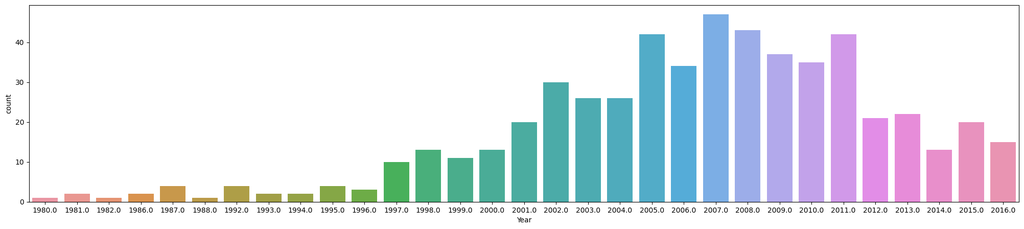

```python
graph = sns.countplot(x="Year", data = df)
graph.figure.set_figwidth(25)
graph.figure.set_figheight(5)
```

2. barplot() - собирает данные по значениям категориальной переменной и применяет определённую функцию к значениям соответсвующих групп цифровой переменной, по умолчанию эта функция — среднее.

Описание: Здесь по графику можно сказать, что в Европе большим спросом пользуются гоночные игры. А на втором месте идут шутеры или стрелялки, их отрыв до первого места почти в полтора раза. Менее играбельными стали стретегические игры и приключенченские игры, они ннабрали меньше среднего значения 0,1.

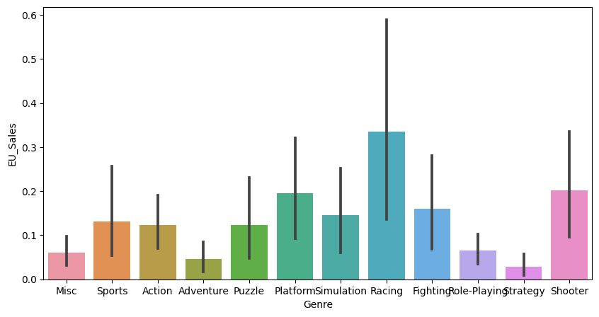

```python
graph = sns.barplot(x=df["Genre"], y=df["EU_Sales"])
graph.figure.set_figwidth(10)
graph.figure.set_figheight(5)
```

3. boxplot() — такой вид диаграммы в удобной форме показывает медиану и другие параметры при необходимости,

минимальное и максимальное значение выборки и выбросы. Расстояния между различными частями ящика позволяют определить степень разброса и асимметрии данных и выявить выбросы. Описание: в японии можем наблюдать, что они мало играют в игры, ведь лидарами можно назвать сразу 4 виды игр: платформенные, стратегии, ролевые и драки. У остальных видов очень маленькие средние показатели, менее 0,1. Но нельзя не выделить, что у экшн-игр были самые успешные выбросы/выпуски некоторых игр.

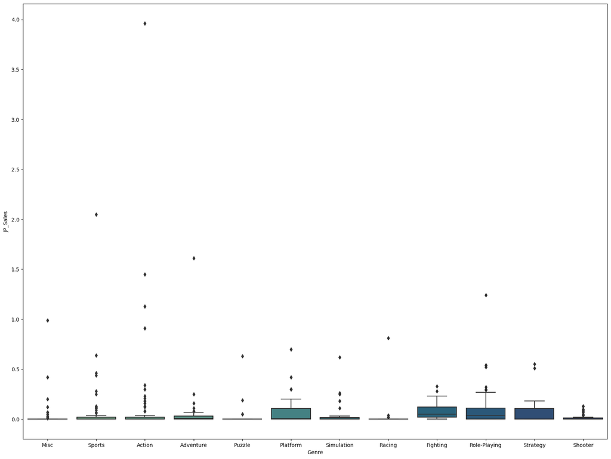

```python
graph = sns.boxplot(x="Genre", y="JP_Sales",data = df,palette='crest')
graph.figure.set_figwidth(20)
graph.figure.set_figheight(15)
```

4. Тепловая карта (heatmap()) - это метод визуализации данных, который показывает величину

явления в виде цвета в двух измерениях. Изменение цвета может быть вызвано оттенком или интенсивностью. Описание: в данном контексте эта диаграмма некорректна, она в большей степени необходима для температурных данных. Поэтому в данном случае по нему ориентироваться на правильность не стоит. Но если все-таки постараться что-то сказать по нему, то зависимость между случайными числами Rang и Global_Sales близка к минимуму из предложенного интервала.

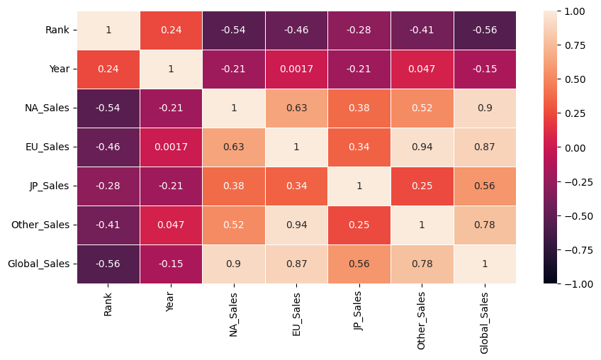

```python
Maks123 = sns.heatmap(df.corr(numeric_only=True), vmin=-1, vmax=1, linewidths=.5, annot=True)
Maks123.figure.set_figwidth(10)
Maks123.figure.set_figheight(5)
```

5.1) pairplot() - по умолчанию эта функция создаст сетку осей таким образом, что каждая числовая переменная в данных будет разделена по осям y в одной строке и по осям x в одном столбце. В данном случае строится одномерный график распределения, показывающий предельное распределение данных в каждом столбце. Описание: в данном случае график демонстрирует сравнение абсолютно всех цифровых столбцов друг с другом. Например, возьмем год Year и Rang, здесь видно в каком году был тот или иной rank. И так происходит со всеми.

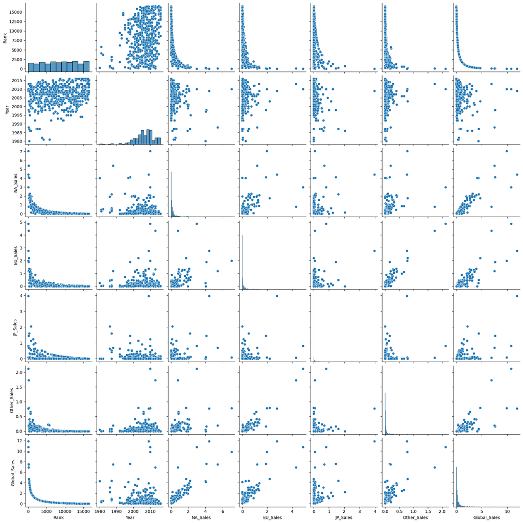

```python
graph = sns.pairplot(df)
```

5.2) PairGrid() - этот объект сопоставляет каждую переменную в наборе данных со столбцом и строкой в сетке из нескольких осей, а предельное распределение каждой переменной может быть показано по диагонали. Описание: эта диаграмма по функционалу точно такая же как и предыдущая, но выводится слегка по-другому за счет соединенных кружков. Поэтому здесь также происходит сравнение абсолютно всех цифровых столбцов друг с другом.

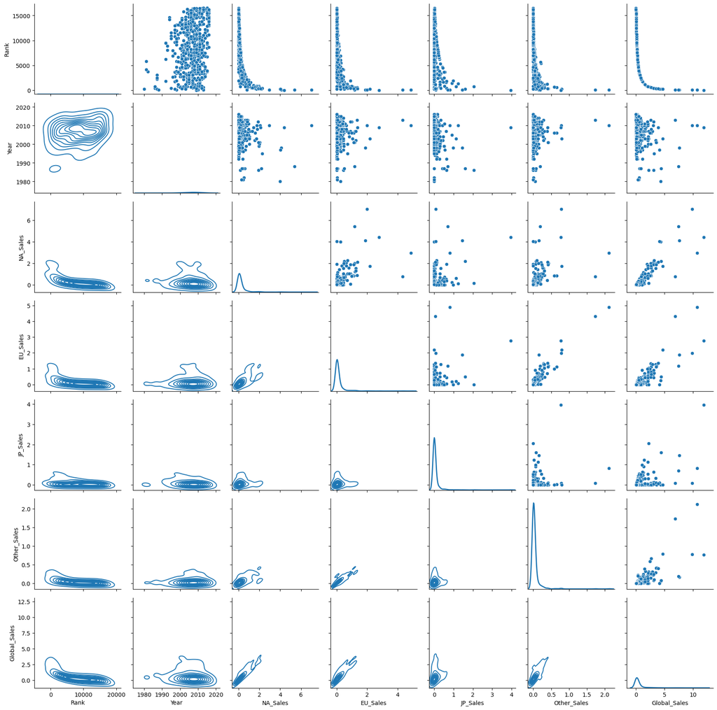

```python
graph = sns.PairGrid(df)
graph = graph.map_upper(sns.scatterplot)
graph = graph.map_lower(sns.kdeplot)
graph = graph.map_diag(sns.kdeplot, lw = 2)
```

6)Кластеризация — это задача группировки множества объектов на подмножества, чтобы объекты из одного подмножества были похожи друг на друга по какому-либо критерию. Описание: здесь сначала выбираем несколько столбцов и берем значения кратные 75 для простоты демонстрации.

```python
df_mini = df[["Global_Sales","EU_Sales","JP_Sales"]][::75]
df_mini
```

|  | Global_Sales | EU_Sales | JP_Sales |
| --- | --- | --- | --- |
| 0 | 0.05 | 0.02 | 0.00 |
| 75 | 4.31 | 0.26 | 0.00 |
| 150 | 0.18 | 0.16 | 0.00 |
| 225 | 0.33 | 0.01 | 0.08 |
| 300 | 0.05 | 0.01 | 0.00 |
| 375 | 0.40 | 0.26 | 0.00 |
| 450 | 0.04 | 0.04 | 0.00 |
| 525 | 0.54 | 0.17 | 0.00 |

```python
model = KMeans(n_clusters=3)
model.fit(df_mini)
all_predictions = model.predict(df_mini)
df_mini["KMeans"] = all_predictions
df_mini
```

|  | Global_Sales | EU_Sales | JP_Sales | KMeans |
| --- | --- | --- | --- | --- |
| 0 | 0.05 | 0.02 | 0.00 | 2 |
| 75 | 4.31 | 0.26 | 0.00 | 1 |
| 150 | 0.18 | 0.16 | 0.00 | 2 |
| 225 | 0.33 | 0.01 | 0.08 | 0 |
| 300 | 0.05 | 0.01 | 0.00 | 2 |
| 375 | 0.40 | 0.26 | 0.00 | 0 |
| 450 | 0.04 | 0.04 | 0.00 | 2 |
| 525 | 0.54 | 0.17 | 0.00 | 0 |

Описание: демонстрация KMeans на самой простой диаграмме,отображающей количество.

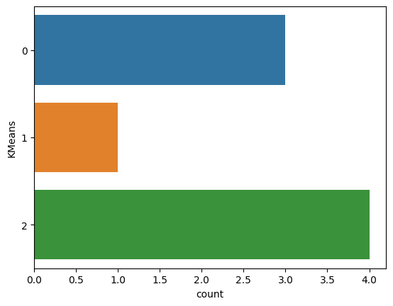

```python
sns.countplot(data = df_mini, y = "KMeans")
```

Описание: демонстрация KMeans на pairplot диаграмме,отображающей нахождения подмножеств из нового столбца в стобцах указанных параметре.

[figure not shown]

```python
sns.pairplot(df_mini,hue="KMeans")
```